# Social Network Analysis

Worksheet 3: Network Concepts and Descriptives I

Author

Termeh Shafie

### Load Packages

```r
library(igraph)
library(networkdata)
library(netUtils)
```

### To start off…

Load the following two datasets

```r
data("tailor_social")
data("tailor_work")
```

**Which of the two networks is directed and how can you verify this?**

**Solution**

**Show solution**

```r
# print both and check for `--` and `->` edges or "UN" and "DN"
tailor_social
tailor_work

#str from netUtils prints the type explicitly
str(tailor_social)
str(tailor_work)

is_directed(tailor_social)
is_directed(tailor_work)
```

### Exercise: Reading network data

- load all network files in `data.zip` into R and create appropriate igraph objects
- calculate the density of the networks
- calculate local and global transitivity (if possible)
- check if the global transitivity differs from a random graph (see slide 60; choose one network or all)

**Solution**

**Show solution**

```r
#net1
tab <- read.csv("data/net1.csv",header = TRUE,row.names = 1,sep = " ")
class(tab)
A <- as.matrix(tab)
graph_from_adjacency_matrix(A)
#check if the matrix is symmetric
A == t(A)

net1 <- graph_from_adjacency_matrix(A,mode = "undirected",weighted = TRUE,diag = FALSE)

#net2
tab <- read.csv("data/net2.csv",header = TRUE, sep = ",")
#graph_from_edgelist(tab)
el <- as.matrix(tab)
net2 <- graph_from_edgelist(el,directed = FALSE)

#net3
tab <- read.csv("data/net3.csv",header = TRUE, sep="\t")
el <- as.matrix(tab)
net3 <- graph_from_edgelist(el[,1:2],directed = FALSE)

E(net3)$weight <- tab[,3]
net3 <- set_edge_attr(net3,name = "weight",value = tab[,3])

#net4
tab <- read.csv("data/net4.csv",header = TRUE,row.names = 1,sep = ",")
class(tab)
A <- as.matrix(tab)
#check if the matrix is symmetric
A == t(A)
net4 <- graph_from_adjacency_matrix(A,mode = "directed",weighted = TRUE,diag = FALSE)

#net5
tab <- read.csv("data/net5.csv",header = TRUE,row.names = 1,sep = "\t")
class(tab)
A <- as.matrix(tab)

#check if the matrix is symmetric
A == t(A)
net5 <- graph_from_adjacency_matrix(A,mode = "directed",weighted = TRUE,diag = FALSE)
```

### Netreader Addin

*(Interactive Session)*

### Exercise: Create networks

Try to create igraph objects for the following networks:

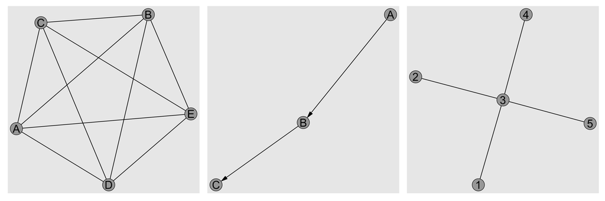

Choose one network (you can also do more) and do the following:

- add `names` as a node attribute
- add an edge attribute `weight` and assign it values of your choice
- find a way to extract the edgelist and the adjacency matrix of the networks

**Solution**

**Show solution**

```r
library(patchwork)
library(ggraph)
g1 <- make_full_graph(5)
V(g1)$name <- LETTERS[1:5]
#g1 <- graph_from_literal(A:B:C:D:E -- A:B:C:D:E)

p1 <- ggraph(g1,"stress")+
   geom_edge_link0()+
   geom_node_point(shape=21,fill="grey66",size=10)+
   geom_node_text(aes(label=name), size = 7)

g2 <- make_graph(edges = c("A","B","B","C"))
#g2 <- graph_from_literal( A -+ B -+ C )
#g2 <- make_ring(3,directed = TRUE,circular = FALSE)

p2 <- ggraph(g2,"stress")+
   geom_edge_link(arrow = arrow(angle = 15, length = unit(0.15, "inches"), ends = "last", type = "closed"),end_cap=circle(12,"pt"),n=2)+
   geom_node_point(shape=21,fill="grey66",size=10)+
   geom_node_text(aes(label=name), size= 7)

g3 <- make_star(5,"undirected",center = 3)
V(g3)$name <- 1:5
p3 <- ggraph(g3,"stress")+
   geom_edge_link0()+
   geom_node_point(shape=21,fill="grey66",size=10)+
   geom_node_text(aes(label=name), size = 7)

p1 + p2 + p3
```

## Structural features

### Exercise: Degree Distribution

```r
pa <- sample_pa(1500, power = 1.5, m = 3, directed = FALSE)
er <- sample_gnp(1500, p = 0.003)
```

- Verify that the networks have approximately the same density
- Plot the degree distributions of both networks and check for skewness
- calculate the degrees (`degree()`) and order the sequence decreasingly (`order()`)
- For both networks, create a loop (i=1,…, 50) which deletes the top i vertices (`delete_vertices()`) in the ordered degree sequence and compute the diameter of the resulting networks
- What can you observe?

**Solution**

**Show solution**

```r
#calculate the density (edge_density is the same as graph.density)
edge_density(pa)
edge_density(er)

# for the preferential attachment network,
# we plot the degree distribution on a log-log scale
# a straight-ish line should appear
plot(degree_distribution(pa), log="xy")
plot(degree_distribution(er))

#calculate the degrees explicitly
deg_er <- order(degree(er),decreasing = TRUE)
deg_pa <- order(degree(pa),decreasing = TRUE)

# iterate through the top 50 nodes, delete them and calculate the diameter
res_er <- rep(0,50)
res_pa <- rep(0,50)

for(i in 1:50){
  g1 <- delete_vertices(er,deg_er[1:i])
  g2 <- delete_vertices(pa,deg_pa[1:i])
  res_er[i] <- diameter(g1)
  res_pa[i] <- diameter(g2)
}

plot(res_pa,type = "l", col="red",ylab="diameter")
lines(res_er,col="black")
```

[output not shown]

You’ll notice that the diameter increases very quickly for a preferential attachment network. The diameter of the random network on the other hand remains constant. If you would redo the analysis for the preferential attachment network and remove random nodes, you’ll notice that the diameter also remains constant. A preferential network is thus said to be **fragile to targeted attacks** but **robust to random attacks**.

### Exercise: Density, Transitivity, Distances

Real world networks tend to have a high transitivity (`transitivity(type="global")`), low average distance (`mean_distance()`) and a low density (`graph.density()`).

- Experiment with `sample_pa()` and `sample_gnp()` and compute the three stats. Can all three criteria be fullfiled? Why/why not?